# Reproducible Research Week 2 Course Project

## Loading and preprocessing the data

```r
unzip("activity.zip")
data <- read.csv("activity.csv", na.strings = "NA")
head(data)
```

```
##   steps       date interval
## 1    NA 2012-10-01        0
## 2    NA 2012-10-01        5
## 3    NA 2012-10-01       10
## 4    NA 2012-10-01       15
## 5    NA 2012-10-01       20
## 6    NA 2012-10-01       25
```

## Loading packages

```r
library(dplyr)
library(ggplot2)
```

## Mean total number of steps per day

The following code creates a new dataset by compiling the total number of steps per day.

```r
data_sum <- aggregate(steps ~ date, data, sum)
```

The following code creates a histogram of the total number of steps per day.

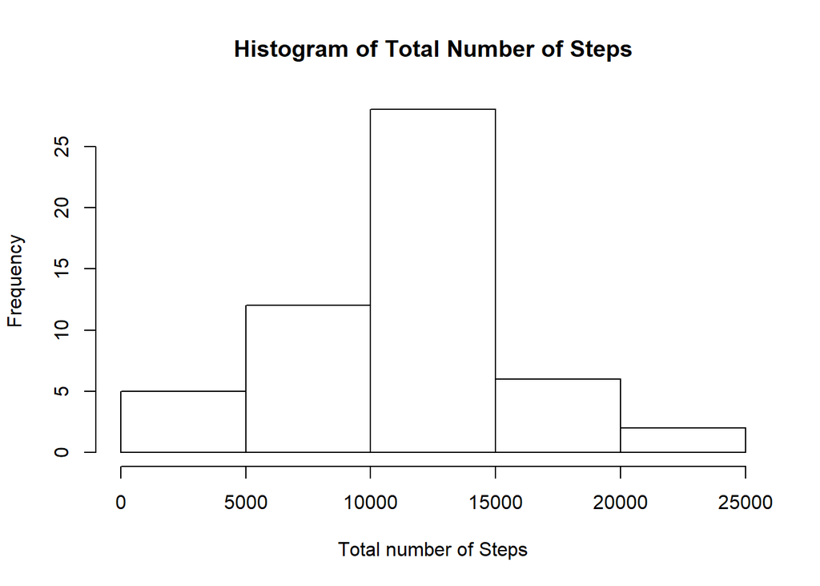

```r
hist(data_sum$steps,
     main="Histogram of Total Number of Steps",
     xlab="Total number of Steps")
```

The following code calculates the mean and median of the total number of steps per day.

```r
mean_steps <- round(mean(data_sum$steps),2)
median_steps <- median(data_sum$steps)
```

The mean number of steps is 10766.19 and the median number of steps is 10765.

## Average daily activity pattern

The following code creates a new dataset by compiling the average number of steps taken by interval.

```r
data_int <- aggregate(steps ~ interval, data, mean)
```

The following code creates a time series plot of the 5-minute interval and average number of steps taken.

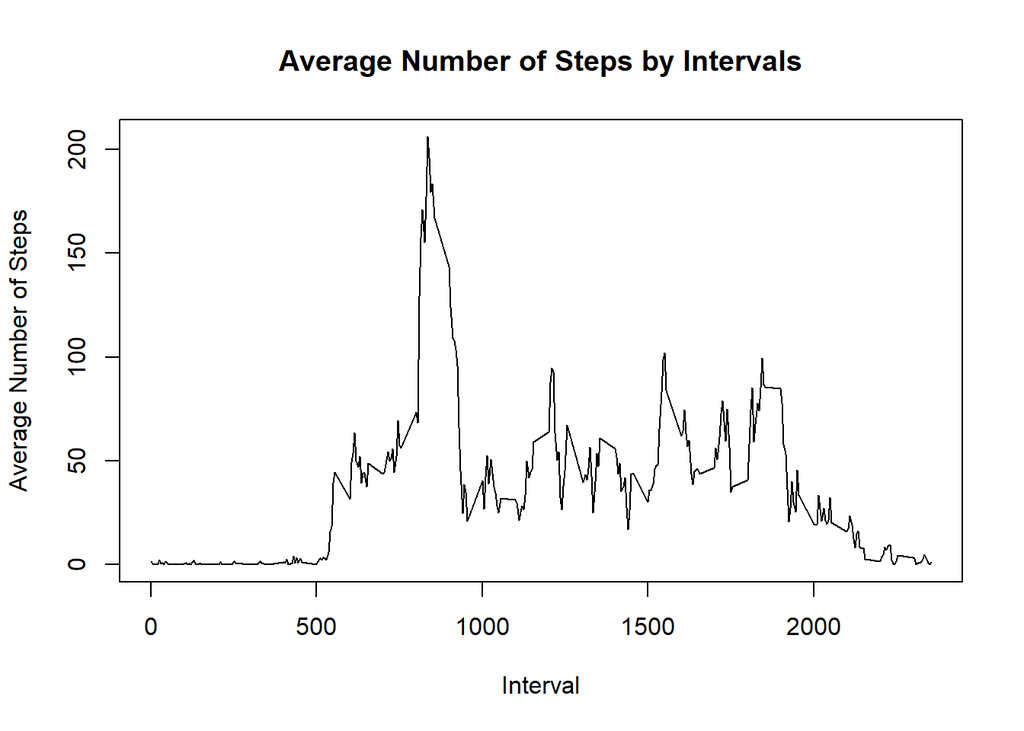

```r
with(data_int, plot(steps ~ interval, type = "l",
     main="Average Number of Steps by Intervals",
     xlab="Interval",
     ylab="Average Number of Steps"))
```

```r
max_steps <- max(data_int$steps)
```

## Imputing missing values

The following code counts the number of rows with missing data.

```r
missing <- sum(is.na(data))
```

The number of missing values is 2304.

```r
data_new <- data
index <- which(is.na(data_new$steps))
l <- length(index)
steps_mean <- with(data_new, tapply(steps, date, mean, na.rm=TRUE))
na <- mean(steps_mean, na.rm=TRUE)
for (i in 1:l) {
        data_new[index[i], 1] <- na
}
```

The following code creates a new dataset by compiling the total number of steps per day.

```r
data_sum_new <- aggregate(steps ~ date, data_new, sum)
```

The following code creates a histogram of the total number of steps per day.

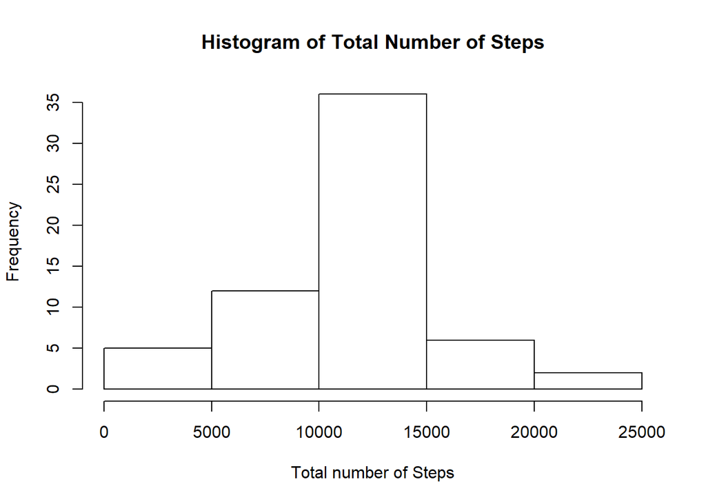

```r
hist(data_sum_new$steps,
     main="Histogram of Total Number of Steps",
     xlab="Total number of Steps")
```

The following code calculates the mean and median of the total number of steps per day.

```r
mean_steps_new <- round(mean(data_sum_new$steps),2)
median_steps_new <- round(median(data_sum_new$steps),2)
```

The mean number of steps is 10766.19 and the median number of steps is 10766.19.

## Differences in activity patterns between weekdays and weekends

The following code creates a new variable that indicates whether the date occurs on a weekend or weekday.

```r
data_new$date <- as.Date(as.character(data_new$date), "%Y-%m-%d")
data_new$dayofweek <- weekdays(data_new$date)
data_new$day <- data_new$dayofweek
for (i in 1:nrow(data_new)) {
        if(data_new[i, ]$day %in% c("Saturday", "Sunday")) {
                data_new[i, ]$day <- "Weekend"
        }
        else{
                data_new[i, ]$day <- "Weekday"
        }
}
```

The following code creates a new dataset of average steps by weekday/weekend.

```r
mean_weekend <- aggregate(steps ~ interval + day, data_new, mean)
```

The following code creates a time series plot that splits the average number of steps by weekday/weekend.

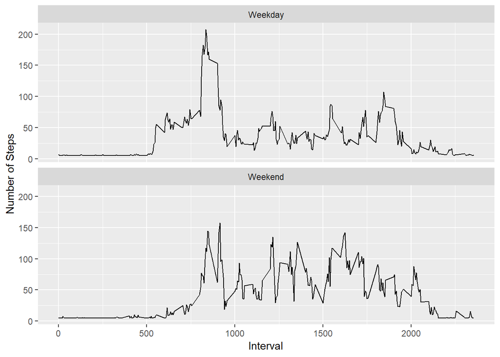

```r
g <- ggplot(mean_weekend, aes(interval, steps))
g + geom_line() +
        facet_wrap(~day, nrow=2) +
        labs(x = "Interval",
             y = "Number of Steps")
```